# Anotaciones

- Anotaciones Java
  - Tipos de anotaciones
    - Predefinidas
      - @Deprecated
      - @Override
      - @SuppressWarnings
      - @SafeVarargs
      - @FunctionalInterface

## Anotaciones Java

Las anotaciones permiten agregar información de **metadatos** al código fuente **desde Java 5 (Septiembre 2004).**

## Metadatos

> Se tratan de datos acerca de los datos.

> En programación, etiquetas de información adicional utilizadas sobre los elementos del lenguaje.

> Una librería o el propio intérprete procesará estas etiquetas de información para tomar decisiones o acciones en el contexto de programa.

### Tipos de anotaciones

#### Predefinidas

##### @Deprecated

La anotación **@Deprecated** indica que el elemento marcado (clase, método o campo) está en desuso (obsoleto) y ya no se debe usar.

El compilador genera una advertencia cada vez que un programa utiliza un método, una clase o un campo que se ha marcado con la anotación **@Deprecated**.

Cuando un elemento está en desuso, también debe documentarse con la etiqueta Javadoc **@deprecated**, como se muestra en el siguiente ejemplo. Hay una diferencia entre mayúsculas y minúsculas con **@Deprecated** y **@deprecated**. **@deprecated** se utiliza con fines de documentación.

```java
/**
 * @deprecated
 * razón por la que se depreca
 */
@Deprecated
public void unMetodo(){
    //
}
```

##### @Override

Al sobrescribir un método en la clase hija o o implementar una interfaz, debemos usar esta anotación para marcar ese método.

Esto hace que el código sea legible y evita problemas de mantenimiento, como:

Al cambiar la firma del método de la clase principal, debe cambiar la firma en las clases secundarias (donde se usa esta anotación), de lo contrario, el compilador arrojaría un error de compilación.

Este tipo de cambios son difíciles de rastrear si no se ha utilizado esta anotación.

```java
public class ClasePadre {

    public void unMetodo() {
        System.out.println("Método de la clase padre");
    }
}


public class ClaseHija extends ClasePadre {

    @Override
    public void unMetodo() {
        System.out.println("Método de la clase hija");
    }
}
```

##### @SuppressWarnings

Esta anotación indica al compilador que ignore advertencias específicas.

Por ejemplo, en el siguiente código, se llama a un método en desuso (supongamos que el método metodoDeprecado() está marcado con la anotación **@Deprecated**), por lo que el compilador genera una advertencia.

Sin embargo, puedo suprimir esa advertencia de obsolescencia mediante la anotación **@SuppressWarnings**.

```java
@SuppressWarnings("deprecation")
    void metodo() {
        myObj.metodoDeprecado();
}
```

##### @SafeVarargs

**Java 5** introdujo el concepto de **varargs**, o un parámetro de método de longitud variable, así como los tipos parametrizados (genéricos).

Combinar ambos causa problemas:

```java
public static <T> T[] unsafe(T... elements) {
    return elements; // Método inseguro, nunca devolver varargs con tipo parametrizado T
}

public static <T> T[] broken(T semilla) {
    T[] plant =unsafe(semilla, semilla, semilla); //Se rompe! Será un Object[] independientemente de T
    return plant;
}

public static void plant() {
   String[] plants = broken("semilla"); // Va a la lanzar una ClassCastException
}
```

El uso de **varargs** junto con genéricos **T…** es difícil de verificar para el compilador, por lo que emite advertencias cada vez que se combinan los dos, como en el caso anterior:

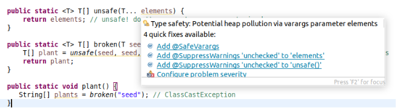

Para eliminar esta advertencia, podemos agregar la anotación **@SafeVarargs** en métodos y constructores finales o estáticos.

**@SafeVarargs** es como **@SupressWarnings** que nos permite declarar que una advertencia particular del compilador es un falso positivo.

Una vez que nos aseguremos de que nuestras acciones son seguras, podemos agregar esta anotación:

```java
public class Machine<T> {
    private List<T> versions = new ArrayList<>();

    @SafeVarargs
    public final void safe(T... toAdd) {
        for (T version : toAdd) {
            versions.add(version);
        }
    }
}
```

## Interfaz Funcional

> Una interfaz funcional es aquella interfaz que **sólo dispone de un método (abstracto)**.

Recordemos que desde **Java 8 (marzo 2014)** las interfaces Java han evolucionado con características como disponer de métodos por defecto (default que se heredan automáticamente implementados en todas las clases que implementen la interfaz).

Ejemplo de una interfaz funcional_

```java
public class Calculadora {

   interface Matematicas {

      public double operacion(double x, double y);

   }

   public static void main(String[] args) {

      Matematicas o = (x, y) -> x + y; // lambda, o función anónima
      System.out.println(o.operacion(2, 3));

      o = (x, y) -> x * y;
      System.out.println(o.operacion(4, 6));

   }

}
```

Si modificamos la interfaz y añadimos un nuevo método (abstracto) a la interfaz Matematicas → **el programa no compila**: el compilador nos avisa de que esa interfaz ha dejado de ser una interfaz funcional.

## Recuerda

> Las interfaces funcionales únicamente disponen de un método abstracto.

por este motivo la asignación de la lambda o función anónima no se podrá realizar, recibiéndose aviso del compilador.

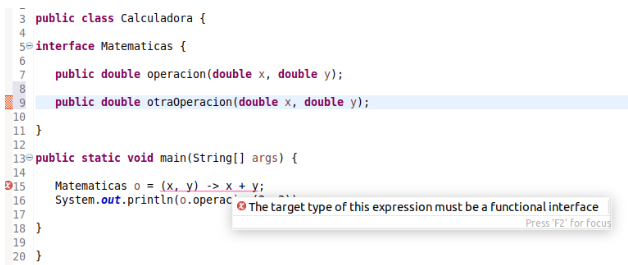

Para evitar este tipo de problemas se usa la anotación **@FunctionalInterface** que obliga al desarrollador a solo incluir un método abstracto.

```java
public class Calculadora {

    @FunctionalInterface
    interface Matematicas {

       public double operacion(double x, double y);

    }

    public static void main(String[] args) {

       Matematicas o = (x, y) -> x + y;
       System.out.println(o.operacion(2, 3));

    }

}
```

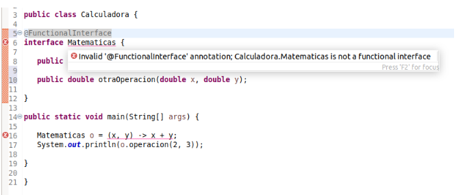

## Meta-anotaciones

> Anotaciones sobre anotaciones

> Anotaciones que sirven para definir anotaciones y cómo deben comportarse.

Anotaciones para indicar al compilador cómo debe tratar una nueva **anotación personalizada**(creada por el programador).

##### @Retention

Esta anotación especifica el ámbito donde se encuentra disponible la anotación marcada con ella.

Este ámbito puede ser:

- sólo al código fuente (**RetentionPolicy.SOURCE**),
- incrustado en el archivo de clase generado (**RetentionPolicy.CLASS**),
- o también disponible en tiempo de ejecución a través de la API de reflection (**RetentionPolicy.RUNTIME**).

```java
import java.lang.annotation.Retention;
import java.lang.annotation.RetentionPolicy;

//@Retention(RetentionPolicy.CLASS)
@Retention(RetentionPolicy.RUNTIME)
//@Retention(RetentionPolicy.SOURCE)
public @interface MyCustomAnnotation
{
  //some code
}
```

##### @Documented

Esta anotación indica que se debe incluir una nueva anotación en los documentos generados por las herramientas de generación de documentos Java (javadoc).

```java
import java.lang.annotation.Documented;

@Documented
public @interface MyCustomAnnotation {
   //Some other code
}
```

##### @Target

para indicar en qué parte del código se puede utilizar la anotación que se define.

```java
import java.lang.annotation.ElementType;
import java.lang.annotation.Target;

@Target(value = {ElementType.TYPE, ElementType.METHOD, ElementType.CONSTRUCTOR,
                 ElementType.ANNOTATION_TYPE, ElementType.FIELD, ElementType.LOCAL_VARIABLE,
                 ElementType.PACKAGE, ElementType.PARAMETER})
public @interface MyCustomAnnotation {
   //Some other code
}
```

##### @Inherited

Indicará que la anotación marcada con ella se hereda en el esquema de herencia de clases de Java.

Por ejemplo, **@MyCustomAnnotation** lleva la meta-anotación **@Inherited**. Entonces, cuando **@MyCustomAnnotation** se aplica a cualquier clase MyParentClass, la anotación **@MyCustomAnnotation** también estará disponible para todas las clases hijas de MyParentClass.

## Herencia de anotaciones

> Por defecto, las anotaciones aplicadas en la clase PADRE no están disponibles para las clases HIJAS, salvo que estas anotaciones estén marcadas con **@Inherited**.

```java
import java.lang.annotation.Inherited;

@Inherited
public @interface MyCustomAnnotation {
   //Some other code
}
```

##### @Repeatable

Por defecto, una anotación se puede aplicar a un elemento Java **sólo una vez**.

Pero si, por algún requisito, se debe aplicar una anotación más de una vez, se debe usar la meta-anotación **@Repeatable**, disponbile desde la última versión de **Java 8**.

```java
import java.lang.annotation.Repeatable;

@Retention(RetentionPolicy.RUNTIME)
@Target(ElementType.TYPE)
@Repeatable(Schedules.class)
public @interface Schedule {
  String dayOfMonth() default "first";
  String dayOfWeek() default "Mon";
  int hour() default 12;
}

@Retention(RetentionPolicy.RUNTIME)
@Target(ElementType.TYPE)
public @interface Schedules {
    Schedule[] value();
}
```

A partir de esta defición mediante **@Repeatable** se puede repetir la anotación sobre un mismo elemento, como en el ejemplo siguiente:

```java
@Schedule(dayOfMonth="last")
@Schedule(dayOfWeek="Fri", hour="23")
public void doPeriodicCleanup() { ... }
```